# Colg/Crest

Gonzalo Carretero Ursúa

11/22/2020

```r
knitr::opts_chunk$set(include =  TRUE)
```

```r
library(readxl)
library(TSA)
```

```r
library(ggplot2)
library(forecast)
library(zoo)
library(Hmisc)
library(dplyr)
library(magrittr)
library(xts)
```

# Dataset

```r
data <- data <- read_excel("data.xlsx")
```

# Limpieza y Representación Gráfica

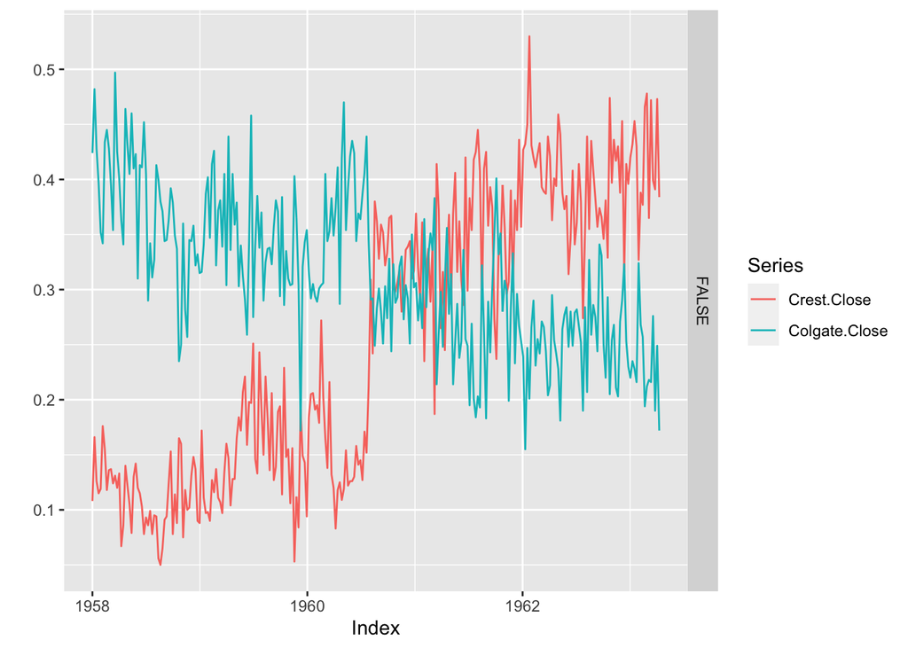

```r
date <- seq(as.Date("1958-01-01"), as.Date("1963-04-15"), by = "week")
data %<>% select(c(-Year, -Week))
attach(data)
Crest <- xts(Crest, order.by = date)
Colgate <- xts(Colgate, order.by = date)
Crest.Week <- to.weekly(Crest)
Colgate.Week <- to.weekly(Colgate)
Crest = as.zoo(Crest.Week$Crest.Close)
Colgate = as.zoo(Colgate.Week$Colgate.Close)

autoplot(cbind(Crest, Colgate), facets = F)
```

Observando el gráfico vemos en ambas series patrones de tendencia, positiva para Crest y negativa para Colgate, y variabilidad en varianza. Por tanto, se concluye que ninguna de las dos series es estacionaria.

# Transformación logarítmica

Se aplican logaritmos para transformar las series en series estacionarias en varianza. Aplicamos una diferencia para tratar de ver la serie estacionaria en media

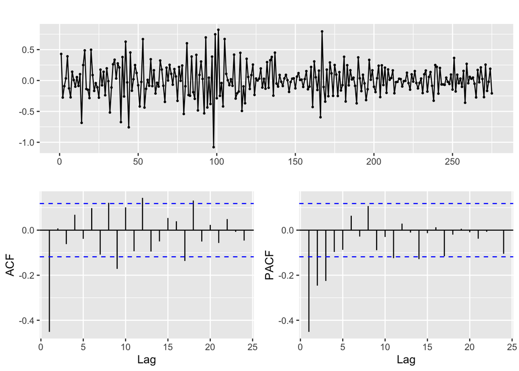

```r
Crest.Var <- log(Crest)
Colgate.Var <- log(Colgate)
ggtsdisplay(diff(Crest.Var))
```

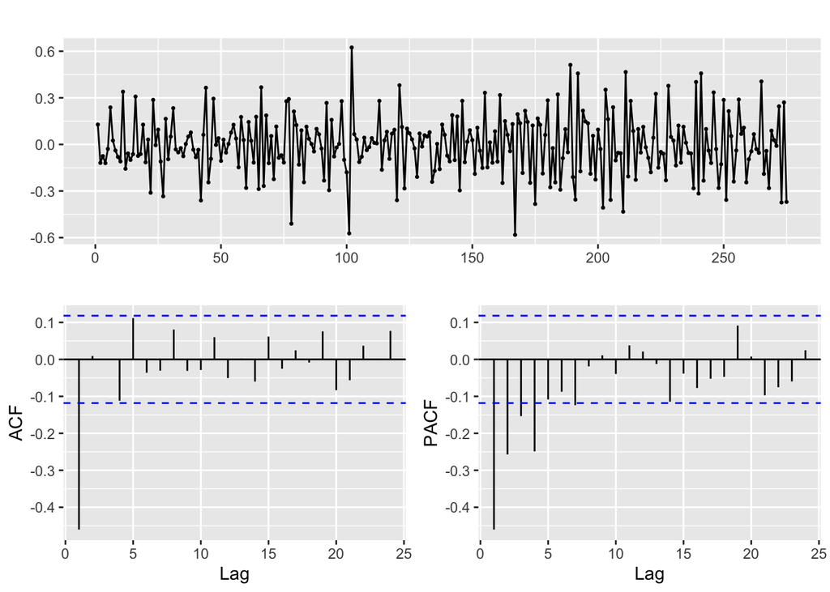

```r
ggtsdisplay(diff(Colgate.Var))
```

# ARIMA CREST

```r
c= 16 # 16 semanas que debemos predecir
n = length(Crest.Var)
o_crest <- window(x = Crest.Var,
                    start = index(Crest.Var[1]),
                    end = index(Crest.Var[n - c]))

Crest.Arima <- auto.arima(o_crest)
summary(Crest.Arima)
```

```
## Series: o_crest
## ARIMA(0,1,1)
##
## Coefficients:
##           ma1
##       -0.6377
## s.e.   0.0471
##
## sigma^2 estimated as 0.05107:  log likelihood=17.94
## AIC=-31.89   AICc=-31.84   BIC=-24.77
##
## Training set error measures:
##                      ME      RMSE       MAE       MPE     MAPE      MASE
## Training set 0.01269669 0.2251133 0.1683403 -2.528429 11.28135 0.1083138
##                      ACF1
## Training set -0.006409037
```

```r
Crest.Forc = forecast(Crest.Arima, h = 16)
Crest.Forc
```

```
##       Point Forecast     Lo 80      Hi 80     Lo 95      Hi 95
## -2563     -0.9353508 -1.224961 -0.6457405 -1.378272 -0.4924300
## -2556     -0.9353508 -1.243386 -0.6273157 -1.406450 -0.4642517
## -2549     -0.9353508 -1.260769 -0.6099324 -1.433035 -0.4376662
## -2542     -0.9353508 -1.277270 -0.5934317 -1.458271 -0.4124306
## -2535     -0.9353508 -1.293010 -0.5776915 -1.482344 -0.3883580
## -2528     -0.9353508 -1.308086 -0.5626153 -1.505401 -0.3653011
## -2521     -0.9353508 -1.322576 -0.5481258 -1.527561 -0.3431412
## -2514     -0.9353508 -1.336543 -0.5341591 -1.548921 -0.3217811
## -2507     -0.9353508 -1.350039 -0.5206626 -1.569562 -0.3011400
## -2500     -0.9353508 -1.363110 -0.5075918 -1.589552 -0.2811498
## -2493     -0.9353508 -1.375793 -0.4949086 -1.608949 -0.2617526
## -2486     -0.9353508 -1.388121 -0.4825806 -1.627803 -0.2428986
## -2479     -0.9353508 -1.400122 -0.4705795 -1.646157 -0.2245444
## -2472     -0.9353508 -1.411821 -0.4588806 -1.664049 -0.2066525
## -2465     -0.9353508 -1.423240 -0.4474621 -1.681512 -0.1891894
## -2458     -0.9353508 -1.434397 -0.4363048 -1.698576 -0.1721258
```

R nos devuelve un modelo ARIMA (0,1,1). Es decir, un modelo con un retardo en la parte de media móvil y una diferencia.

# Representación gráfica de la predicción ARIMA para Crest

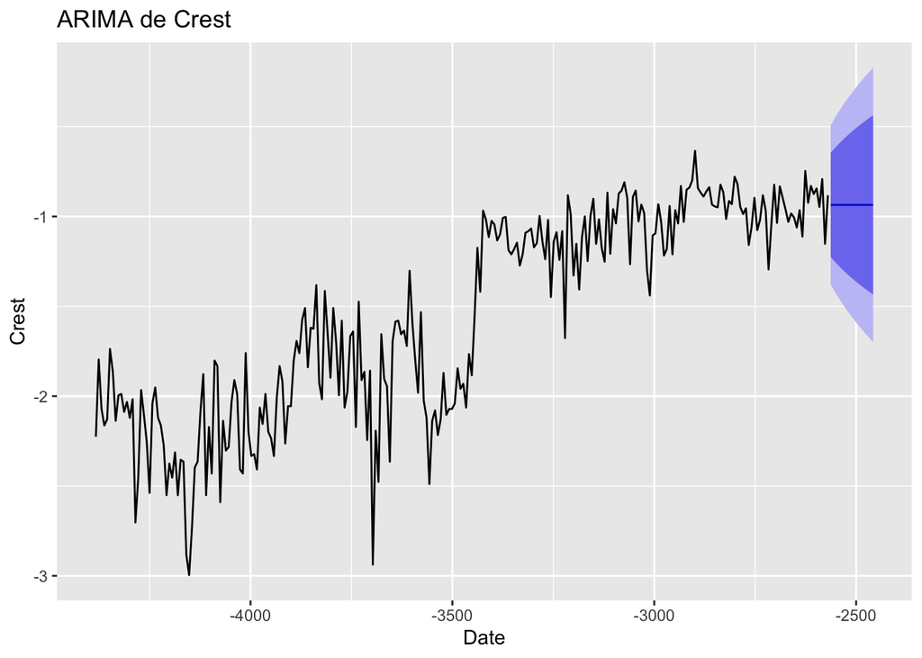

```r
autoplot(Crest.Forc, main = "ARIMA de Crest") +
  xlab("Date") +
  ylab("Crest")
```

# ARIMA COLGATE

```r
c = 16
n = length(Colgate.Var)
o_colgate <- window(x = Colgate.Var,
                      start = index(Colgate.Var[1]),
                      end = index(Colgate.Var[n - c]))
Colgate.Arima <- auto.arima(o_colgate)
summary(Colgate.Arima)
```

```
## Series: o_colgate
## ARIMA(0,1,1)
##
## Coefficients:
##           ma1
##       -0.7688
## s.e.   0.0480
##
## sigma^2 estimated as 0.02572:  log likelihood=106.6
## AIC=-209.2   AICc=-209.15   BIC=-202.08
##
## Training set error measures:
##                        ME      RMSE      MAE        MPE     MAPE      MASE
## Training set -0.008080012 0.1597463 0.123498 -0.8343985 10.59627 0.1055543
##                    ACF1
## Training set 0.04624703
```

```r
Colgate.Forc = forecast(Colgate.Arima, h = 16)
Colgate.Forc
```

```
##       Point Forecast     Lo 80     Hi 80     Lo 95      Hi 95
## -2563      -1.330718 -1.536234 -1.125203 -1.645027 -1.0164103
## -2556      -1.330718 -1.541655 -1.119782 -1.653318 -1.0081192
## -2549      -1.330718 -1.546940 -1.114497 -1.661401 -1.0000359
## -2542      -1.330718 -1.552099 -1.109338 -1.669291 -0.9921455
## -2535      -1.330718 -1.557141 -1.104296 -1.677002 -0.9844349
## -2528      -1.330718 -1.562073 -1.099364 -1.684545 -0.9768923
## -2521      -1.330718 -1.566902 -1.094535 -1.691930 -0.9695072
## -2514      -1.330718 -1.571634 -1.089803 -1.699167 -0.9622700
## -2507      -1.330718 -1.576275 -1.085162 -1.706265 -0.9551723
## -2500      -1.330718 -1.580830 -1.080607 -1.713231 -0.9482063
## -2493      -1.330718 -1.585303 -1.076134 -1.720072 -0.9413648
## -2486      -1.330718 -1.589699 -1.071738 -1.726795 -0.9346416
## -2479      -1.330718 -1.594022 -1.067415 -1.733406 -0.9280305
## -2472      -1.330718 -1.598275 -1.063162 -1.739911 -0.9215263
## -2465      -1.330718 -1.602461 -1.058976 -1.746313 -0.9151238
## -2458      -1.330718 -1.606584 -1.054853 -1.752618 -0.9088185
```

R nos devuelve un modelo ARIMA (0,1,1) para Colgate

# Representación gráfica de la predicción de Colgate

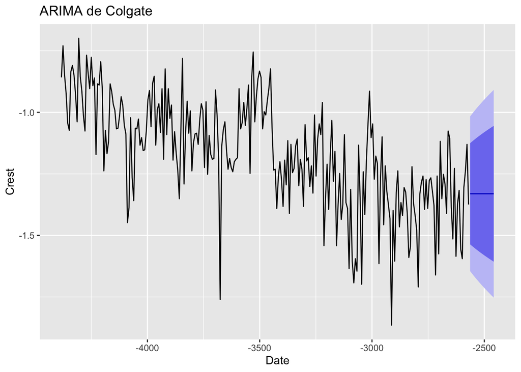

```r
autoplot(Colgate.Forc, main = "ARIMA de Colgate") +
  xlab("Date") +
  ylab("Crest")
```

# Residuos de los modelos ARIMA

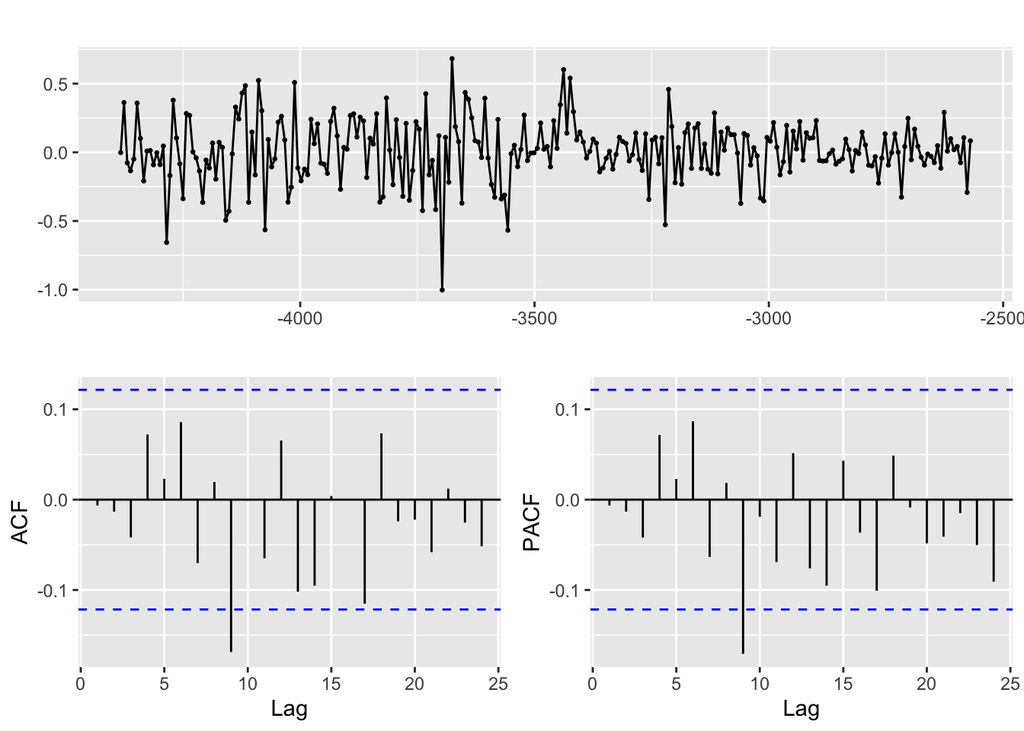

```r
ggtsdisplay(Crest.Arima$residuals)
```

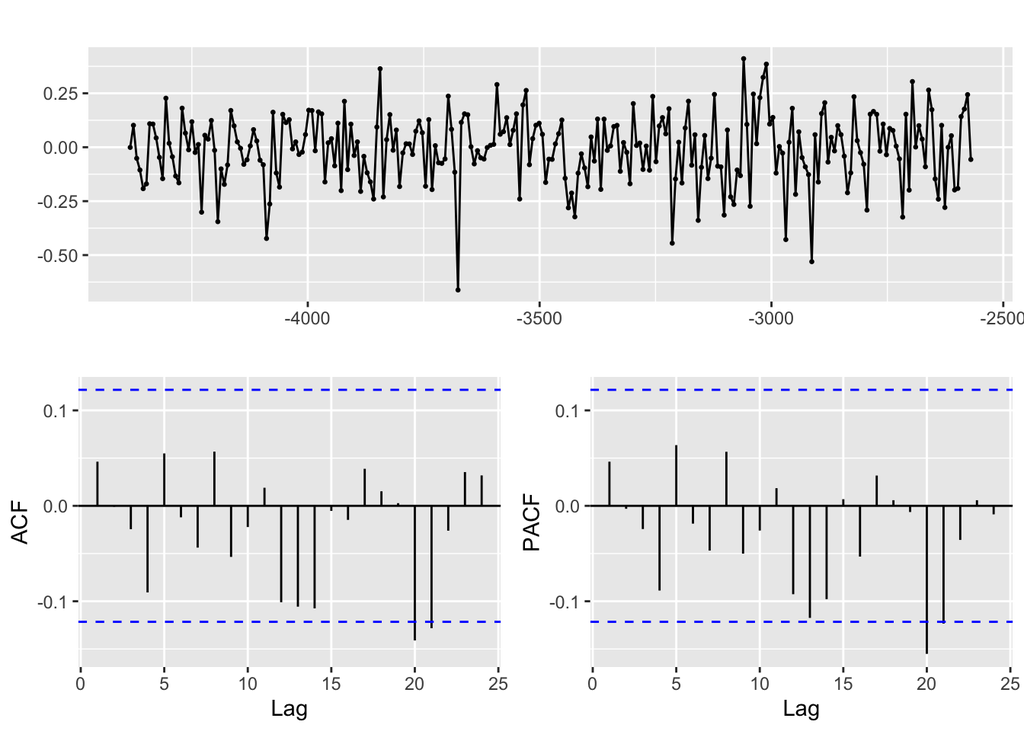

```r
ggtsdisplay(Colgate.Arima$residuals)
```

Se obsevan retardos en los residuos, tanto para Colgate como para Crest, que muestran cierta correlación. Es decir que no son ruido blanco y, por tanto, no se distribuyen cómo una normal (0,1). Con esto se concluye que estos modelos ARIMA no son óptimos para predecir